# lab5

How Data was Collected

What are Jets:

Jets are cones of particles that are ejected from a collision, the particles in the jet are produced by the hadronization of a quark or gluon, which is the process where hadrons are created from quarks and gluons. When an object containing color charge fragments, each fragment carries away some of the color charge. In order to obey confinement, these fragments create other colored objects around them to form colorless objects. All of these objects tend to travel in close to the same direction, hence the narrow cone. So these objects that form are what make up jets.

```python
# Reading Data
import numpy as np
import matplotlib
import matplotlib.pyplot as plt
import scipy
from scipy import stats
import pickle

# open the file of interest, and use pickle loading
infile = open ("higgs_100000_pt_1000_1200.pkl",'rb')
higgs_dict = pickle.load(infile)

infile = open ("qcd_100000_pt_1000_1200.pkl",'rb')
qcd_dict = pickle.load(infile)

# list all keys of the files
qcd_dict.shape
```

```
(100000, 14)
```

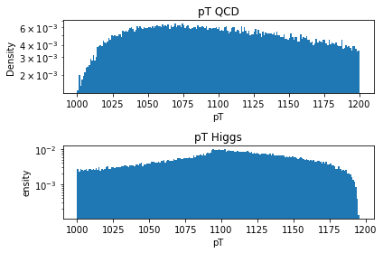

```python
#for i in range(100):
 #print(higgs_dict['mass'][i],qcd_dict['mass'][i])
fig, ax = plt.subplots(2)
ax[0].hist(qcd_dict['pt'], bins=200, density=True)
ax[1].hist(higgs_dict['pt'], bins=200, density=True)
ax[0].set_yscale('log')
ax[1].set_yscale('log')
ax[0].set_title('pT QCD')
ax[1].set_title('pT Higgs')
ax[0].set_xlabel('pT')
ax[0].set_ylabel('Density')
ax[1].set_xlabel('pT')
ax[1].set_ylabel('ensity')
plt.tight_layout()
```

The first variable in the jet is pT, which is the transverse momentum. It is the momentum of the jet, that is perpendicular to the direction that the beam is traveling. The total transeverse momentum of a jet is the sum of the transverse momentum of all of the particles making up a jet. For this experiment, the data contains values for pT between 1000, and 1200 Gev.

The plot above shows a histogram of the pT values for all of the data from the higgs signal dataset, and the QCD background dataset.

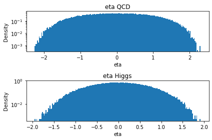

```python
fig, ax = plt.subplots(2)
ax[0].hist(qcd_dict['eta'], bins=200, density=True)
ax[1].hist(higgs_dict['eta'], bins=200, density=True)
ax[0].set_yscale('log')
ax[1].set_yscale('log')
ax[0].set_title('eta QCD')
ax[1].set_title('eta Higgs')
ax[0].set_xlabel('eta')
ax[0].set_ylabel('Density')
ax[1].set_xlabel('eta')
ax[1].set_ylabel('Density')
plt.tight_layout()
```

The second variable is $\eta$. $\eta$ is variable that is based on the angle of separation $\theta$ that a jet is from the direction of beam travel. It goes from -$\infty$ to $\infty$ as $\theta$ goes from 0 to $\pi$. If $\theta$ = 90, the $\eta$ = 0

$\eta$ = -$\ln\cot\frac{\theta}{2}$

The above plot shows a histogram of the $\eta$ values for both the higgs signal dataset, and the QCD background dataset.

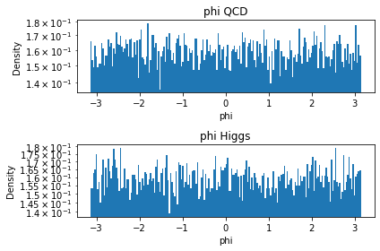

```python
fig, ax = plt.subplots(2)
ax[0].hist(qcd_dict['phi'], bins=200, density=True)
ax[1].hist(higgs_dict['phi'], bins=200, density=True)
ax[0].set_yscale('log')
ax[1].set_yscale('log')
ax[0].set_title('phi QCD')
ax[1].set_title('phi Higgs')
ax[0].set_xlabel('phi')
ax[0].set_ylabel('Density')
ax[1].set_xlabel('phi')
ax[1].set_ylabel('Density')
plt.tight_layout()
```

The third variable is $\phi$, which is the azimuthal angle going around the beam of particles. $\phi$ is used with $\eta$ to determine the location of a jet, in the detector.

The above plot shows a histogram of the $\phi$ values for both the higgs signal dataset, and the QCD background dataset.

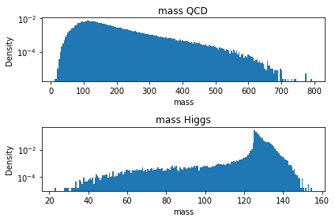

```python
fig, ax = plt.subplots(2)
ax[0].hist(qcd_dict['mass'], bins=200, density=True)
ax[1].hist(higgs_dict['mass'], bins=200, density=True)
ax[0].set_yscale('log')
ax[1].set_yscale('log')
ax[0].set_title('mass QCD')
ax[1].set_title('mass Higgs')
ax[0].set_xlabel('mass')
ax[0].set_ylabel('Density')
ax[1].set_xlabel('mass')
ax[1].set_ylabel('Density')
plt.tight_layout()
```

The fourth variable is the mass of the jet. The mass of the jet, is the measured mass of all of the particles within a jet.

The above plot shows a histogram of the mass values for both the higgs signal dataset, and the QCD background dataset.

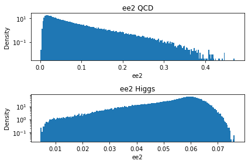

```python
fig, ax = plt.subplots(2)
ax[0].hist(qcd_dict['ee2'], bins=200, density=True)
ax[1].hist(higgs_dict['ee2'], bins=200, density=True)
ax[0].set_yscale('log')
ax[1].set_yscale('log')
ax[0].set_title('ee2 QCD')
ax[1].set_title('ee2 Higgs')
ax[0].set_xlabel('ee2')
ax[0].set_ylabel('Density')
ax[1].set_xlabel('ee2')
ax[1].set_ylabel('Density')
plt.tight_layout()
```

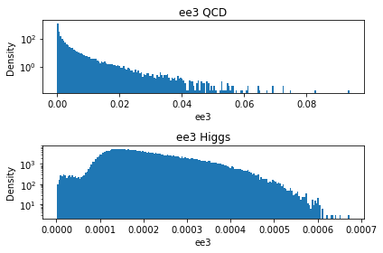

```python
fig, ax = plt.subplots(2)
ax[0].hist(qcd_dict['ee3'], bins=200, density=True)
ax[1].hist(higgs_dict['ee3'], bins=200, density=True)
ax[0].set_yscale('log')
ax[1].set_yscale('log')
ax[0].set_title('ee3 QCD')
ax[1].set_title('ee3 Higgs')
ax[0].set_xlabel('ee3')
ax[0].set_ylabel('Density')
ax[1].set_xlabel('ee3')
ax[1].set_ylabel('Density')
plt.tight_layout()
```

The fifth and sixth varibles are ee2, and ee3 denoted as $e_{2}$ and $e_{3}$. These values are Energy Correlation Ratios.

The equation below is the energy correlation

$E_{CFN}(\beta)$ = $\sum_{i<j \in J}$ $p_{Ti}p_{Tj}(\Delta$$R_{ij})^\beta$

$e_{2}$ and $e_{3}$ are the ratios of the energy correlations:

$e_{2}$ = $\frac{E_{CF2}}{E_{CF1}}$

$e_{3}$ = $\frac{E_{CF3}}{E_{CF2}}$

The above plots show histograms of the ee2 and ee3 values for both the higgs signal dataset, and the QCD background dataset.

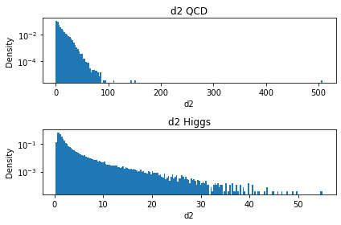

```python
fig, ax = plt.subplots(2)
ax[0].hist(qcd_dict['d2'], bins=200, density=True)
ax[1].hist(higgs_dict['d2'], bins=200, density=True)
ax[0].set_yscale('log')
ax[1].set_yscale('log')
ax[0].set_title('d2 QCD')
ax[1].set_title('d2 Higgs')
ax[0].set_xlabel('d2')
ax[0].set_ylabel('Density')
ax[1].set_xlabel('d2')
ax[1].set_ylabel('Density')
plt.tight_layout()
```

The seventh variable is $D_{2}$. $D_{2}$ is a ratio of ee3, and ee2, so it is also an energy correlation ratio, it is useful for determining a two-body substructure within a jet, which is a jet that is made up of primarily two subjets.

$D_{2}$ = $\frac{e_{3}}{e_{2}^3}$

The above plot shows a histogram of the $D_{2}$ values for both the higgs signal dataset, and the QCD background dataset.

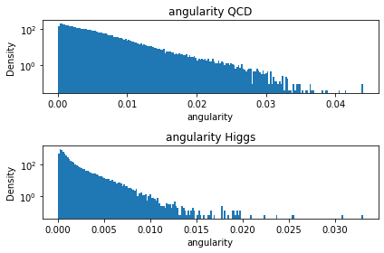

```python
fig, ax = plt.subplots(2)
ax[0].hist(qcd_dict['angularity'], bins=200, density=True)
ax[1].hist(higgs_dict['angularity'], bins=200, density=True)
ax[0].set_yscale('log')
ax[1].set_yscale('log')
ax[0].set_title('angularity QCD')
ax[1].set_title('angularity Higgs')
ax[0].set_xlabel('angularity')
ax[0].set_ylabel('Density')
ax[1].set_xlabel('angularity')
ax[1].set_ylabel('Density')
plt.tight_layout()
```

The eigth variable is angularity denoted by $\tau$. Angularity is a measurement of where the energy in a jet is located, or how it flows, this means it is useful for determining if subjets exist within a jet that is being measured.

$\tau$ = $\frac{1}{M}$$\sum_{i}E_{i}\sin{\theta_{i}(1-\cos{\theta_{i}})}$

The above plot shows a histogram of the angularity values for both the higgs signal dataset, and the QCD background dataset.

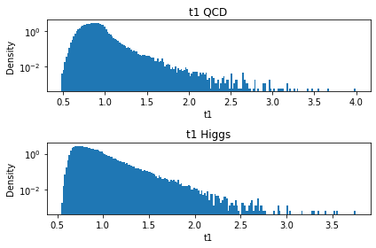

```python
fig, ax = plt.subplots(2)
ax[0].hist(qcd_dict['t1'], bins=200, density=True)
ax[1].hist(higgs_dict['t1'], bins=200, density=True)
ax[0].set_yscale('log')
ax[1].set_yscale('log')
ax[0].set_title('t1 QCD')
ax[1].set_title('t1 Higgs')
ax[0].set_xlabel('t1')
ax[0].set_ylabel('Density')
ax[1].set_xlabel('t1')
ax[1].set_ylabel('Density')
plt.tight_layout()
```

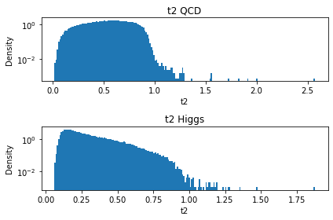

```python
fig, ax = plt.subplots(2)
ax[0].hist(qcd_dict['t2'], bins=200, density=True)
ax[1].hist(higgs_dict['t2'], bins=200, density=True)
ax[0].set_yscale('log')
ax[1].set_yscale('log')
ax[0].set_title('t2 QCD')
ax[1].set_title('t2 Higgs')
ax[0].set_xlabel('t2')
ax[0].set_ylabel('Density')
ax[1].set_xlabel('t2')
ax[1].set_ylabel('Density')
plt.tight_layout()
```

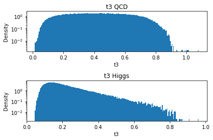

```python
fig, ax = plt.subplots(2)
ax[0].hist(qcd_dict['t3'], bins=200, density=True)
ax[1].hist(higgs_dict['t3'], bins=200, density=True)
ax[0].set_yscale('log')
ax[1].set_yscale('log')
ax[0].set_title('t3 QCD')
ax[1].set_title('t3 Higgs')
ax[0].set_xlabel('t3')
ax[0].set_ylabel('Density')
ax[1].set_xlabel('t3')
ax[1].set_ylabel('Density')
plt.tight_layout()
```

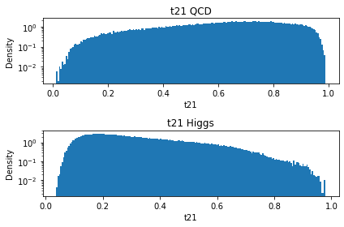

```python
fig, ax = plt.subplots(2)
ax[0].hist(qcd_dict['t21'], bins=200, density=True)
ax[1].hist(higgs_dict['t21'], bins=200, density=True)
ax[0].set_yscale('log')
ax[1].set_yscale('log')
ax[0].set_title('t21 QCD')
ax[1].set_title('t21 Higgs')
ax[0].set_xlabel('t21')
ax[0].set_ylabel('Density')
ax[1].set_xlabel('t21')
ax[1].set_ylabel('Density')
plt.tight_layout()
```

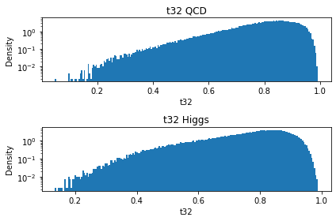

```python
fig, ax = plt.subplots(2)
ax[0].hist(qcd_dict['t32'], bins=200, density=True)
ax[1].hist(higgs_dict['t32'], bins=200, density=True)
ax[0].set_yscale('log')
ax[1].set_yscale('log')
ax[0].set_title('t32 QCD')
ax[1].set_title('t32 Higgs')
ax[0].set_xlabel('t32')
ax[0].set_ylabel('Density')
ax[1].set_xlabel('t32')
ax[1].set_ylabel('Density')
plt.tight_layout()
```

The above five variables are the subjettiness variables. Subjettiness is a measure of how a jet can be made up of subjets

$\tau_{N}$ = $\frac{1}{\tau_{0}}$$\sum_{i}\in Jp_{Ti}$min($\Delta$$R_{1}...R{N}$)

N is the subjet axis and can take on integer values, and $R_{N}$ is the distance between the $i$th subjet, and the subjet axis N.

$\tau_{21}$, and $\tau_{32}$ are the ratios of $\tau_{N}$ values between consecutive values of N

$\tau_{21}$ = $\frac{\tau_{2}}{\tau_{1}}$

$\tau_{32}$ = $\frac{\tau_{3}}{\tau_{2}}$

Like $D_{2}$ these ratios are useful in determining two body substructures in jets.

The above plots show histograms of the t1, t2, t3, t21, and t32 values for both the higgs signal dataset, and the QCD background dataset.

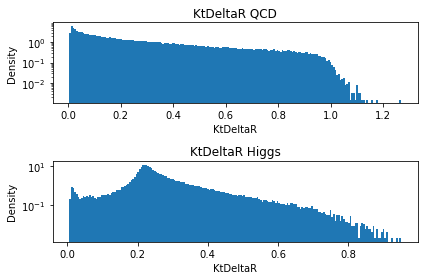

```python
fig, ax = plt.subplots(2)
ax[0].hist(qcd_dict['KtDeltaR'], bins=200, density=True)
ax[1].hist(higgs_dict['KtDeltaR'], bins=200, density=True)
ax[0].set_yscale('log')
ax[1].set_yscale('log')
ax[0].set_title('KtDeltaR QCD')
ax[1].set_title('KtDeltaR Higgs')
ax[0].set_xlabel('KtDeltaR')
ax[0].set_ylabel('Density')
ax[1].set_xlabel('KtDeltaR')
ax[1].set_ylabel('Density')
plt.tight_layout()
```

The final variable is $Kt\Delta$$R$. This is a measurement of distance between two subjets within a a jet of radius $R$

The above plot shows a histogram of the $Kt\Delta$$R$ values for both the higgs signal dataset, and the QCD background dataset.

Correlation:

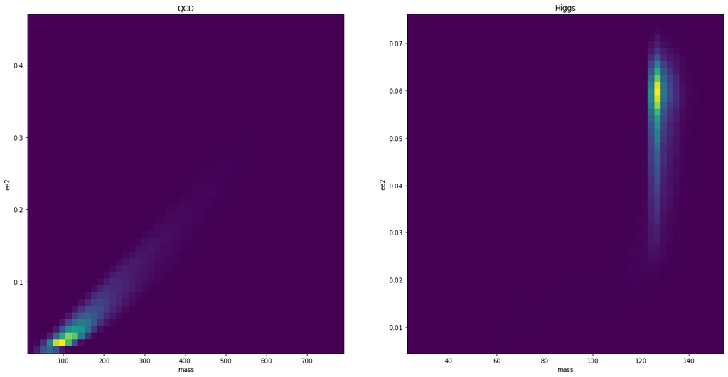

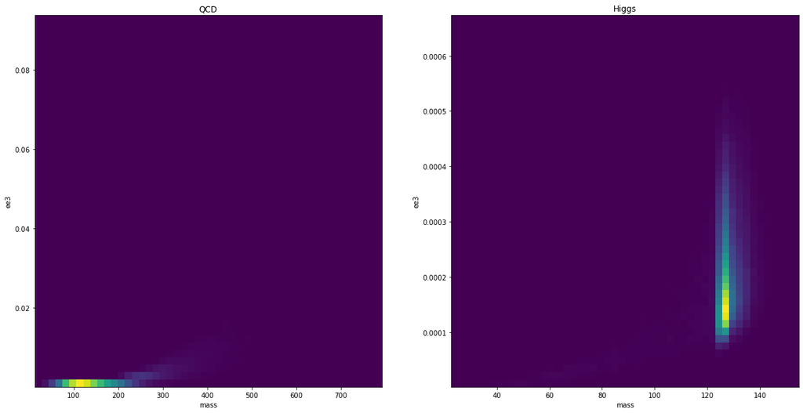

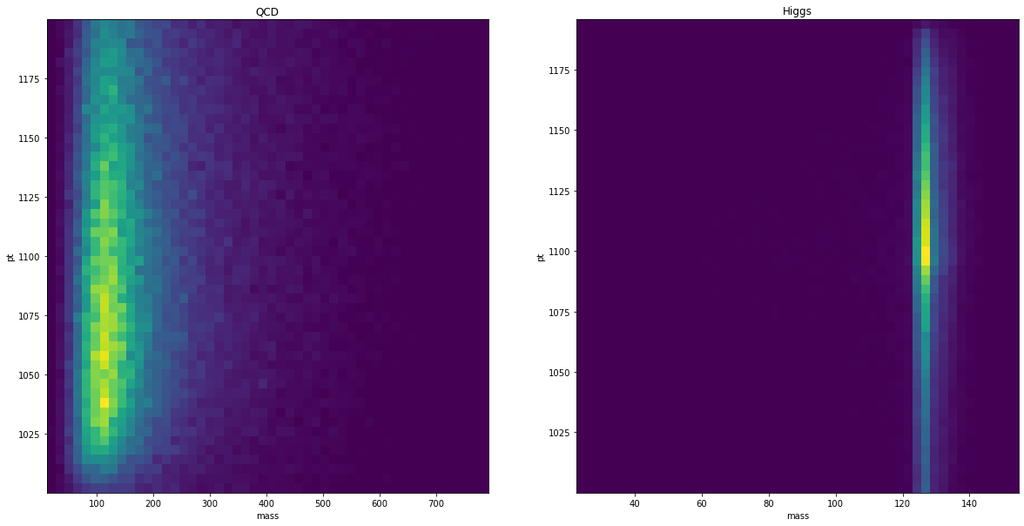

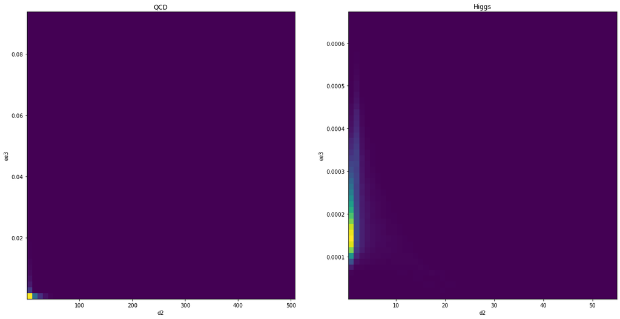

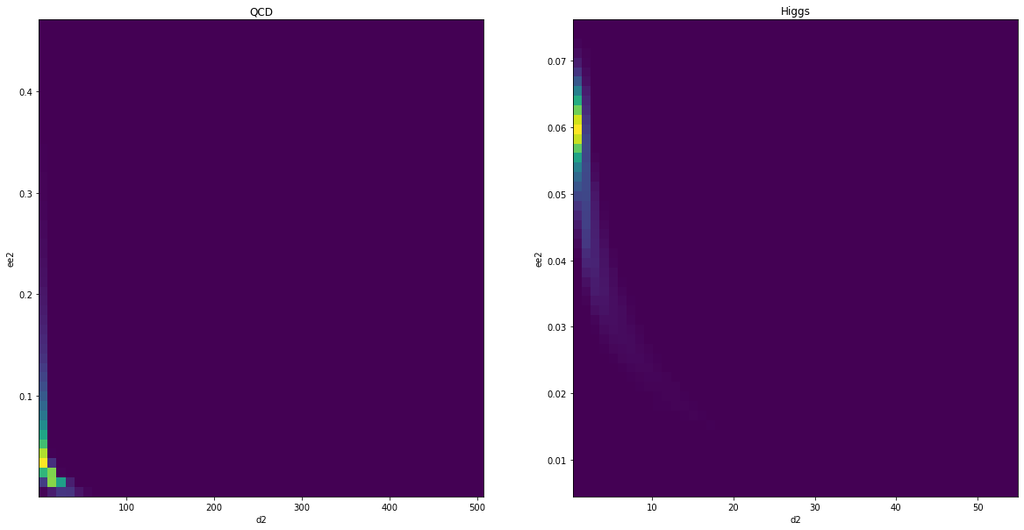

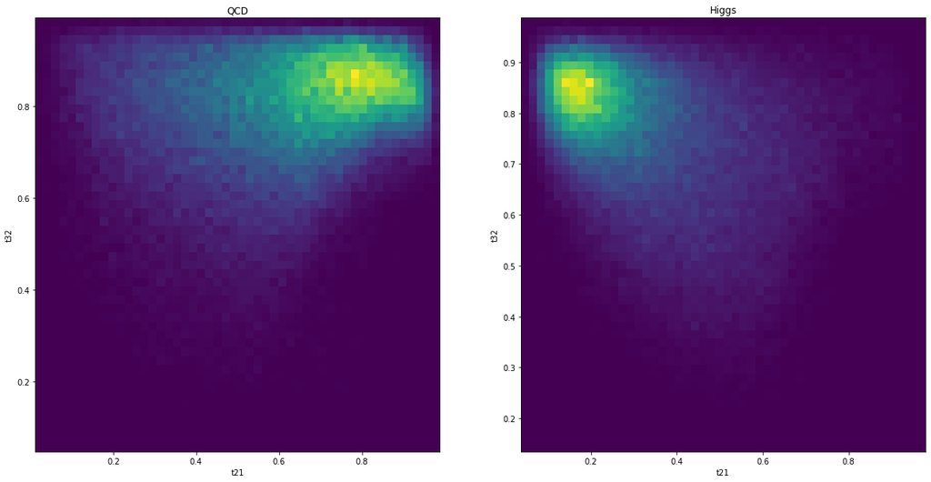

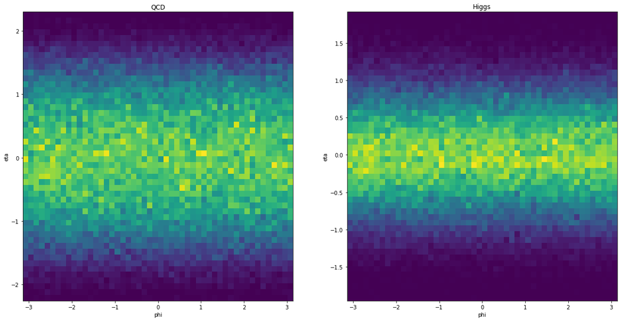

```python
def makeHists(var1, var2):
    fig, ax = plt.subplots(1,2, figsize = (20,10))
    ax[0].hist2d(qcd_dict[var1], qcd_dict[var2], bins=[50,50])
    ax[1].hist2d(higgs_dict[var1], higgs_dict[var2], bins=[50,50])
    ax[0].set_title('QCD')
    ax[1].set_title('Higgs')
    ax[0].set_xlabel(var1)
    ax[0].set_ylabel(var2)
    ax[1].set_xlabel(var1)
    ax[1].set_ylabel(var2)


makeHists('mass', 'ee2')
makeHists('mass', 'ee3')
makeHists('mass', 'pt')
makeHists('d2', 'ee3')
makeHists('d2', 'ee2')
makeHists('t21', 't32')
makeHists('phi', 'eta')
```

Calculating discovery significance:

In order to be sure that a higgs event has occured, we need to insure that the number of higgs events occurring in a dataset it above the five sigma threshold for higgs events occurring in the background. Due to this being a particle physics experiment, the number of higgs events occurring will follow a poisson distribution, and can be represented by a poisson distribution that has a mean equal to the expected yield of higgs events.

```python
sigma_5_prob = 3.5*10**-6
expected_yield_qcd = 2000
threshold = stats.poisson.isf(q=sigma_5_prob,mu=expected_yield_qcd)
print(threshold)
```

```
2204.0
```

Without any data cuts, we would need to observe 2204 higgs events in the QCD background to ensure the discovery of a higgs boson.

Plan to increase sensitivity:

When comparing the higgs signal dataset to the QCD background dataset, it can be seen for certain variables, the higgs signal exists within a small subset of the total background, The standouts being angularity, d2, ee3, ee2, and the mass. By taking values within these ranges from the background, I will be able to cut a significant chunk of data from the background, and increase the sensitivity of significance.